# 3.0. Cross Validation: Introduction

In the initial chapters when we were learning to fit different models, we followed the practice of partitioning the data into a training set and a test set. We built the model on the training set and reported its performance on the test set. The main intention of any model building activity is to develop a generalized model on the available data which will perform well on the unseen data. But to estimate a model’s performance on unseen data, we need to simulate that unseen data using the data that we have available. This is achieved by splitting our available data into training and testing sets. By following this simple principle we ensure that we don’t evaluate the model on the data that it has already seen and been trained on.

In theory, we can extend the same principles for tuning our algorithm. We can evaluate the performance of particular values of the model hyperparameters on the test set. Retrain the model with a different partition of training and test set with a different values of hyperparameters. If the new parameters perform better than the old ones we take them and keep repeating the same process until we have the optimal values of the hyperparameters. This scheme of things is simple but it suffers from a serious flaw. It induces a bias in the model development process. Although the test set is changed in every iteration, the data is being seen by the model to make some choices about the model development process (as we tune and build the model). Hence, the models that we develop end up being biased and not well-generalized and their performance may or may not reflect their performance on unseen data.

A simple change in the data splitting process can help us avoid this leakage of unseen data. Suppose we initially made three different subsets of data instead of the original two. One is the usual training set, the second one is the test set and the last one is called a validation set. So we can train our models on the train data evaluate their performance on the validation data to tune model parameters (or even to select among different models). Once we are done with the tuning process, we can evaluate the final model on the really unseen test set and report the performance on the test set as the approximate performance of the model on the real-world unseen data.

In the very essence of things this is the basic principle behind the process of cross validation, as depicted in Figure

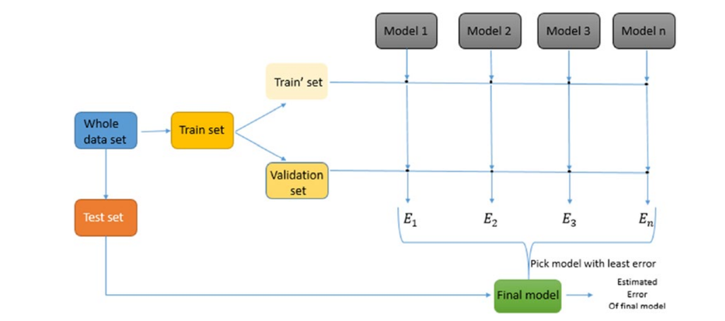

Above figure gives us an idea of how the whole process works. We divide the original dataset into a train and test set. The test set is completely set aside from the learning process. The train set so obtained is again split into an actual train set and a validation set.

The process of model selection is similar irrespective of whether we are assessing completely different models or whether we are trying out different hyperparameter values of the same type of models. Once we have the models developed, we assess their performance on the validation set and select the model with the best performance as the final model.

The previously described process seems to be good. We have described the validation part of the process but we haven’t touched on the cross part of it. So where is the cross-validation? To understand that intricacy of the CV process, we would have to discuss why we need this in the first place. The need for it arises from the fact that by dividing the data into test and a validation set we have lost out on a decent amount of data which we could have used to further refine our modeling process. Also another important point is that if we take a model’s error for a single iteration to be its overall error we are making a serious mistake. Instead we want to take some average measure of error by building multiple iterations of the same model. But if we keep rebuilding the model on the same dataset, we are not going to get much difference in the model performance. We address these two issues by introducing the cross concept of cross-validation.

The idea of cross validation is to get different splits of train and validation sets (different observations in each set, each time) using some strategy (which we will elaborate on later) and then build multiple iterations of each model on these different splits. The average error on these splits is then reported as the error of the model in question and the final decision is made on this averaged error metric. This strategy has a brilliant effect on the estimated error of each model, as it ensures that the averaged error is a close approximation of the model’s error on really unseen data (here our test set) and we could also leverage the complete training dataset for building the model. This process is explained pictorially in following figure:

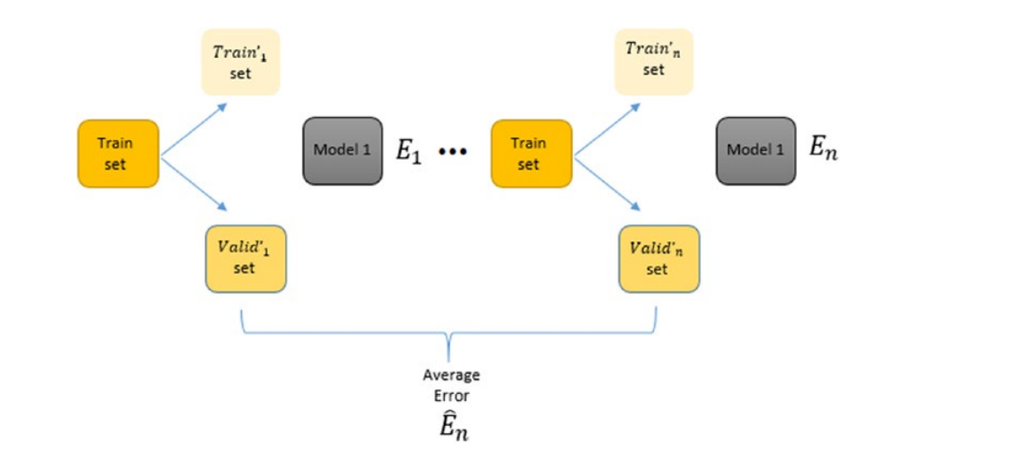

## k-Fold Cross Validation

Cross-validation is a resampling procedure used to evaluate machine learning models on a limited data sample.

**The procedure has a single parameter called k that refers to the number of groups that a given data sample is to be split into**. As such, the procedure is often called k-fold cross-validation. When a specific value for `k` is chosen, it may be used in place of k in the reference to the model, such as `k=5` becoming 5-fold cross-validation.

For K-folds cross validation, we partition the dataset into K bins. We will then run K different learning experiments, each time choosing one bin as the evaluation subset while using the rest to train our algorithm. We can then average the results from all of the experiments to get an accurate picture of it's performance, using the entire dataset (albeit not at the same time) to both train and test the performance of our algorithm. Obviously, this approach will take more time, but it will give a more accurate evaluation of our machine learning model.

If `k=5` the dataset will be divided into 5 equal parts and the below process will run 5 times, each time with a different evaluation subset.

1. Take one group as a evaluation (i.e., validation or test data set)
1. Take the remaining groups as a training data set
1. Fit a model on the training set and evaluate it on the test set
1. Retain the evaluation score and discard the model

At the end of the above process Summarize the skill of the model using the sample of model evaluation scores.

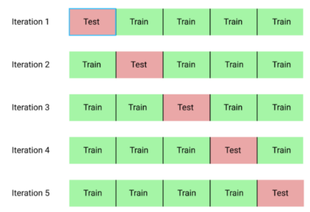

**Choosing value of k**

The k value must be chosen carefully for your data sample.

A poorly chosen value for k may result in a mis-representative idea of the skill of the model, such as a score with a high variance (that may change a lot based on the data used to fit the model), or a high bias, (such as an overestimate of the skill of the model).

The common tactics for choosing a value for k are as follows:

- `k=10`: The value for k is fixed to 10, a value that has been found through experimentation to generally result in a model skill estimate with low bias a modest variance. This approach is called **k-Fold Cross Validation**

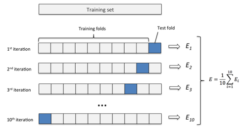

- `k=n`: The value for k is fixed to n, where n is the size of the dataset to give each test sample an opportunity to be used in the hold out dataset. This approach is called **leave-one-out cross-validation**.

## Leave One Out Cross Validation (LOOCV):

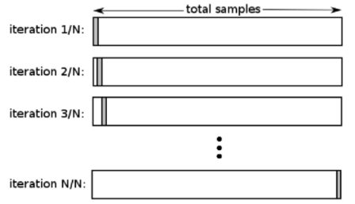

Cross-validation is primarily used in applied machine learning to estimate the skill of a machine learning model on unseen data. That is, to use a limited sample in order to estimate how the model is expected to perform in general when used to make predictions on data not used during the training of the model.

It is a popular method because it is simple to understand and because it generally results in a less biased or less optimistic estimate of the model skill than other methods, such as a simple train/test split.

### k-fold at a glance:

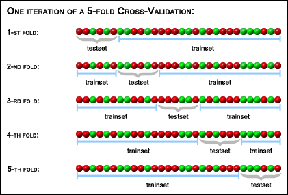

#### LOOCV vs k-Fold CV

k-Fold CV :-

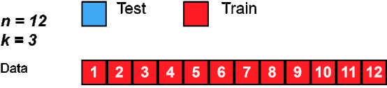

LOOCV :-

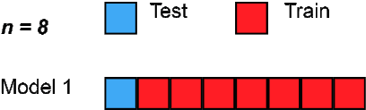

Let’s take a look at our sample dataframe:

```python
import pandas as pd
import numpy as np
target = np.ones(25)
target[-5:] = 0
df = pd.DataFrame({'col_a':np.random.random(25),
                  'target':target})
df
```

|  | col_a | target |
| --- | --- | --- |
| 0 | 0.201530 | 1.0 |
| 1 | 0.988728 | 1.0 |
| 2 | 0.370796 | 1.0 |
| 3 | 0.372560 | 1.0 |
| 4 | 0.880284 | 1.0 |
| 5 | 0.299038 | 1.0 |
| 6 | 0.884756 | 1.0 |
| 7 | 0.983049 | 1.0 |
| 8 | 0.804421 | 1.0 |
| 9 | 0.521272 | 1.0 |
| 10 | 0.508213 | 1.0 |
| 11 | 0.914089 | 1.0 |
| 12 | 0.793242 | 1.0 |
| 13 | 0.584705 | 1.0 |
| 14 | 0.756000 | 1.0 |
| 15 | 0.574057 | 1.0 |
| 16 | 0.187289 | 1.0 |
| 17 | 0.632944 | 1.0 |
| 18 | 0.743974 | 1.0 |
| 19 | 0.951286 | 1.0 |
| 20 | 0.804398 | 0.0 |
| 21 | 0.946384 | 0.0 |
| 22 | 0.065723 | 0.0 |
| 23 | 0.699291 | 0.0 |
| 24 | 0.246634 | 0.0 |

Then we apply `train_test_split` function:

```python
from sklearn.model_selection import train_test_split
X = df.col_a
y = df.target

X_train, X_test, y_train, y_test = train_test_split(X, y, test_size=0.2, shuffle=False)
```

```python
print("TRAIN:", X_train.index, "\n\nTEST:", X_test.index)
```

```
TRAIN: Int64Index([0, 1, 2, 3, 4, 5, 6, 7, 8, 9, 10, 11, 12, 13, 14, 15, 16, 17, 18,
            19],
           dtype='int64')

TEST: Int64Index([20, 21, 22, 23, 24], dtype='int64')
```

The first 80% is training and the last 20% is test set. If we set the shuffle parameter to True, the data will be randomly split:

```python
X_train, X_test, y_train, y_test = train_test_split(X, y, test_size=0.2, shuffle=True)
print("TRAIN:", X_train.index, "\n\nTEST:", X_test.index)
```

```
TRAIN: Int64Index([13, 14, 15, 18, 6, 10, 3, 19, 8, 20, 4, 1, 7, 22, 11, 12, 23, 16,
            9, 5],
           dtype='int64')

TEST: Int64Index([17, 21, 2, 24, 0], dtype='int64')
```

**The default value of shuffle is True so data will be randomly splitted if we do not specify shuffle parameter.** If we want the splits to be reproducible, we also need to pass in an integer to `random_state parameter`. Otherwise, each time we run `train_test_split`, different indices will be splitted into training and test set.

*Note that the numbers seen in the outputs are indices of data points, not the actual values.*

### Applying K-Fold:

```python
from sklearn.model_selection import KFold

X = df.col_a
y = df.target

kf = KFold(n_splits=4)

for train_index, test_index in kf.split(X):
    print("\n\nTRAIN:", train_index, "\nTEST(VAL):", test_index)
```

```
TRAIN: [ 7  8  9 10 11 12 13 14 15 16 17 18 19 20 21 22 23 24]
TEST(VAL): [0 1 2 3 4 5 6]


TRAIN: [ 0  1  2  3  4  5  6 13 14 15 16 17 18 19 20 21 22 23 24]
TEST(VAL): [ 7  8  9 10 11 12]


TRAIN: [ 0  1  2  3  4  5  6  7  8  9 10 11 12 19 20 21 22 23 24]
TEST(VAL): [13 14 15 16 17 18]


TRAIN: [ 0  1  2  3  4  5  6  7  8  9 10 11 12 13 14 15 16 17 18]
TEST(VAL): [19 20 21 22 23 24]
```

```python
kf = KFold(n_splits=4, shuffle=True, random_state=1)
for train_index, test_index in kf.split(X):
    print("\n\nTRAIN:", train_index, "\nTEST(VAL):", test_index)
```

```
TRAIN: [ 0  1  2  4  5  6  7  8  9 11 12 15 16 19 20 22 23 24]
TEST(VAL): [ 3 10 13 14 17 18 21]


TRAIN: [ 0  1  3  5  8  9 10 11 12 13 14 15 16 17 18 21 22 23 24]
TEST(VAL): [ 2  4  6  7 19 20]


TRAIN: [ 2  3  4  5  6  7  8  9 10 11 12 13 14 17 18 19 20 21 23]
TEST(VAL): [ 0  1 15 16 22 24]


TRAIN: [ 0  1  2  3  4  6  7 10 13 14 15 16 17 18 19 20 21 22 24]
TEST(VAL): [ 5  8  9 11 12 23]
```